# Reproducible Research : Peer Assessment 1

James

December 13, 2015

First load some libraries :

```r
library(dplyr)
```

## Loading and preprocessing

First load the datafile and strip out the NAs.

```r
activity <- read.csv("c:/Users/James/activity.csv")
cleaned <- activity[!is.na(activity[,"steps"]),]
#summary(cleaned)
```

## What is the mean number of steps taken per day?

Define a function to

1. Calculate number of steps per day
2. Display a histogram
3. Calculate the mean, median and standard deviation of the number of steps

Then call the function and report the mean and median.

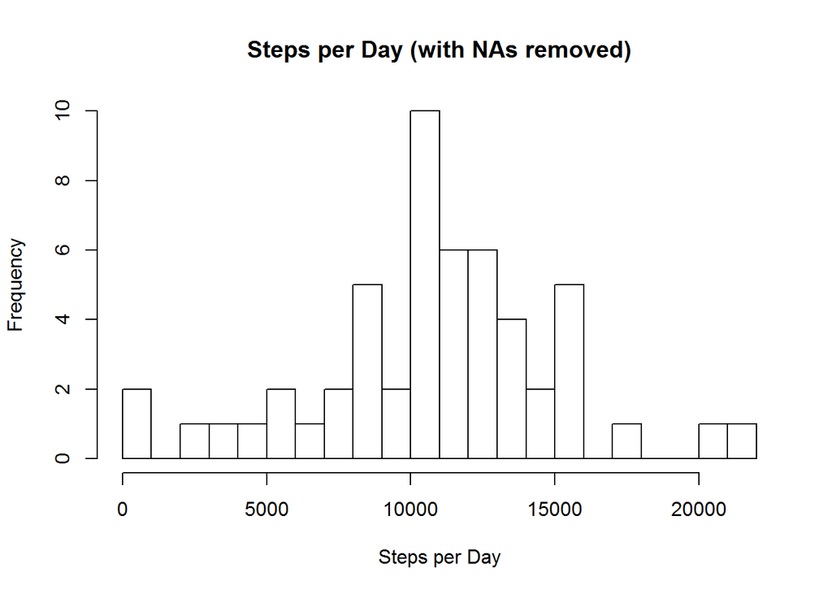

```r
median = 0.0
mean = 0.0
stddev = 0.0
display.histogram = function (data, title)
{
  summary = group_by(data, date) %>% summarise(sum(Steps))
  gdata = as.numeric(summary[["sum(Steps)"]])
  hist(gdata, breaks=20,
       main =paste("Steps per Day", title),
       xlab = "Steps per Day",
       ylab="Frequency")


  median <<- as.integer(median(gdata))
  mean <<- as.integer(mean(gdata))
  stddev <<- as.integer(sd(gdata))
}

cleaned[,"Steps"] = cleaned[,"steps"]
display.histogram(cleaned, "(with NAs removed)")
```

The median number of steps per day is 10765 and the mean is 10766.

## What is the average daily activity pattern?

1. Calculate the average for each interval across all the days.
2. Find the interval with the maximum number of steps on average across all days.

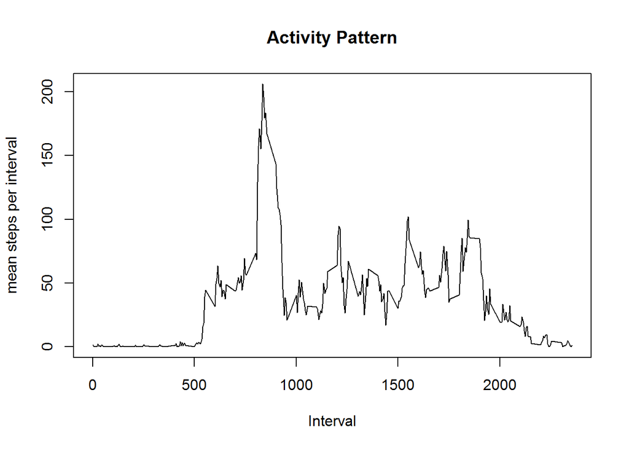

```r
maxInterval = -1
activity.pattern <- function(inputdata, title)
{
  summaryByInterval = group_by(inputdata, interval) %>% summarise(mean(Steps)) %>% arrange(interval)
  plot(summaryByInterval, type="l",
       main = title, xlab = "Interval",
       ylab = "mean steps per interval",
       oma = c (1,1,1,1))
  maxpos = which.max(summaryByInterval[["mean(Steps)"]])
  maxInterval <<- summaryByInterval[["interval"]][maxpos]
}
cleaned[,"Steps"] = cleaned[,"steps"]
activity.pattern(cleaned, "Activity Pattern")
```

The interval with the largest number of steps on average is 835.

## Imputing Missing Values

1. Calculate and report the total number of missing values There are 2304 missing data points.
2. Use the mean average steps for the interval across all days as a default value.
3. Fill in the NA data points with the default value.
4. Plot the histogram and calculate the mean and median using the enriched value.

```r
defaults = group_by(cleaned, interval) %>% summarise(mean(steps))
colnames(defaults)[2] = "default"
enriched = merge(activity, defaults, by="interval")
enriched[,"imputed"] = ifelse(is.na(enriched$steps), enriched$default, enriched$steps)
totalBefore = nrow(activity)
totalAfterwards = nrow(enriched)
summary(enriched[c("steps","imputed")])
```

```
##      steps           imputed
##  Min.   :  0.00   Min.   :  0.00
##  1st Qu.:  0.00   1st Qu.:  0.00
##  Median :  0.00   Median :  0.00
##  Mean   : 37.38   Mean   : 37.38
##  3rd Qu.: 12.00   3rd Qu.: 27.00
##  Max.   :806.00   Max.   :806.00
##  NA's   :2304
```

There were 17568 rows before the enrichment and 17568 rows afterwards, so no rows have been lost. As can be observed from the summary (above) there are no NAs in the “imputed” column.

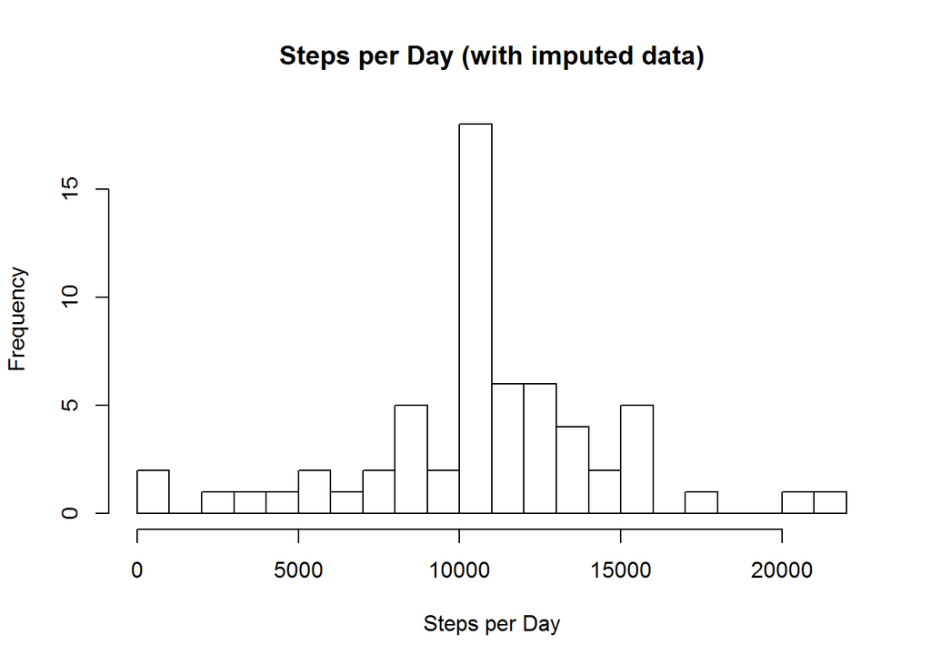

```r
# take care to stash the std dev before so we can compare them below.
sdByRemoving = stddev

enriched[,"Steps"] = enriched[,"imputed"]
display.histogram(enriched, "(with imputed data)")
```

```r
sdByEnriching = stddev
```

The median number of steps per day is 10766 and the mean is 10766. These figures are not materially different from those obtained by excluding the missing data. The main impact of enriching with the mean is that the data are less spread out. This can be observed from the histograms; Furthermore note the standard deviation has dropped from 4269 steps to 3974 steps.

## Are there differences in the activity patterns between weekdays and weekends?

1. Enrich the data with a weekdays/weekend factor variable.
2. Display the activity patterns graph for both weekends and weekdays.

Here a factor variable is added to the enriched data to indicate whether the observation date is on a weekend (ie a Saturday or a Sunday), or on a weekday.

The enriched data is copied into the use steps column and the data is plotted using the same function defined above.

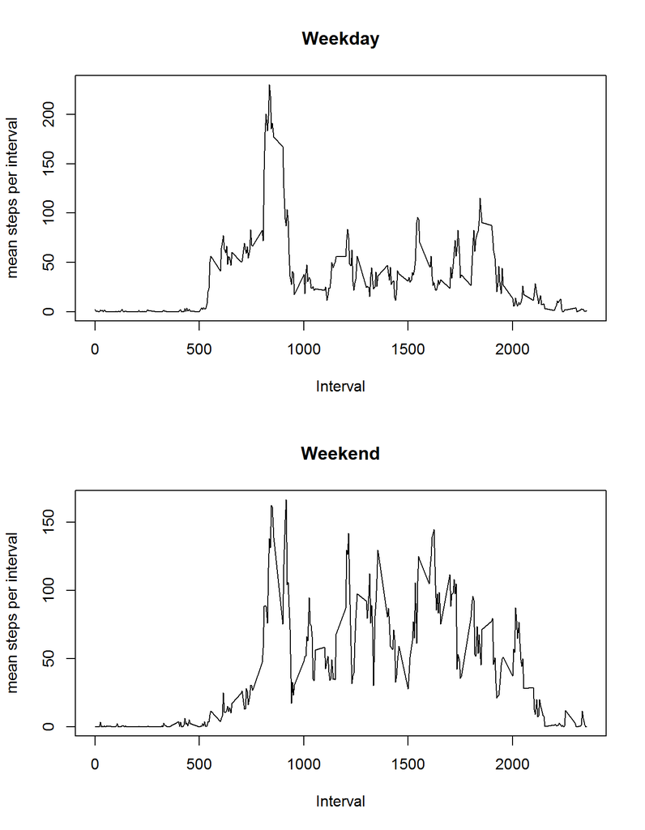

```r
wkddays = as.POSIXlt(enriched[,"date"])$wday
cls = ifelse(wkddays < 1 | wkddays > 5, 1, 0)
enriched[,"classification"] = factor (cls, labels=c("weekday", "weekend"))
enriched[,"Steps"] = enriched[,"imputed"]

par(mfrow=c(2,1))
activity.pattern(filter(enriched, classification == "weekday"), "Weekday")
activity.pattern(filter(enriched, classification == "weekend"), "Weekend")
```